# Generalized Linear Models for Marital Infidelity Analysis

Álvaro Granados Villodre

May 2025

# Introduction

This analysis explores the application of Generalized Linear Models (GLMs) to understand patterns in marital infidelity using behavioral and demographic predictors. The investigation employs both logistic regression for binary classification and Poisson regression for count modeling to examine the factors that influence extramarital behavior.

The dataset contains comprehensive information about marital relationships, including satisfaction levels, religious attitudes, marriage duration, and the presence of children. This study aims to identify the key determinants of infidelity and compare how these factors affect both the probability of being unfaithful and the frequency of extramarital encounters.

# Theoretical Framework

## Generalized Linear Models

Generalized Linear Models extend traditional linear regression to accommodate non-normal response distributions and non-linear relationships through link functions. **In this investigation, two GLM variants are employed: logistic regression for binary outcomes and Poisson regression for count data.**

The GLM framework consists of three components: (1) a probability distribution from the exponential family, (2) a linear predictor combining explanatory variables, and (3) a link function connecting the linear predictor to the expected value of the response variable.

## Dataset Description

The dataset contains observations on marital relationships with the following variables:

- **naffairs**: Number of extramarital affairs within the last year
- **kids**: Presence of children (1=yes, 0=no)
- **Marital satisfaction levels**: vryunhap (very unhappy), unhap (unhappy), avgmarr (average), hapavg (happy average), vryhap (very happy)
- **Religious attitudes**: antirel (anti-religious), notrel (not religious), slghtrel (slightly religious), smerel (somewhat religious), vryrel (very religious)
- **Marriage duration categories**: yrsmarr1 (>0.75 years), yrsmarr2 (>1.5 years), yrsmarr3 (>4.0 years), yrsmarr4 (>7.0 years), yrsmarr5 (>10.0 years), yrsmarr6 (>15.0 years)

# Data Preparation

```r
affairs <- read.csv("http://www-eio.upc.edu/~pau/cms/rdata/csv/COUNT/affairs.csv")
str(affairs)
```

```
## 'data.frame':    601 obs. of  19 variables:
##  $ X       : int  1 2 3 4 5 6 7 8 9 10 ...
##  $ naffairs: int  0 0 3 0 3 0 0 0 7 0 ...
##  $ kids    : int  0 0 0 1 1 1 0 0 1 0 ...
##  $ vryunhap: int  0 0 0 0 0 0 0 0 0 0 ...
##  $ unhap   : int  0 0 0 0 0 0 0 0 1 0 ...
##  $ avgmarr : int  0 0 0 0 0 0 1 0 0 1 ...
##  $ hapavg  : int  1 1 1 1 0 0 0 0 0 0 ...
##  $ vryhap  : int  0 0 0 0 1 1 0 1 0 0 ...
##  $ antirel : int  0 0 0 1 0 0 0 0 0 0 ...
##  $ notrel  : int  0 0 0 0 0 0 1 1 0 1 ...
##  $ slghtrel: int  1 0 1 0 1 0 0 0 0 0 ...
##  $ smerel  : int  0 1 0 0 0 0 0 0 0 0 ...
##  $ vryrel  : int  0 0 0 0 0 1 0 0 1 0 ...
##  $ yrsmarr1: int  0 0 0 0 0 0 1 0 0 1 ...
##  $ yrsmarr2: int  0 0 1 0 0 0 0 1 0 0 ...
##  $ yrsmarr3: int  0 1 0 0 1 0 0 0 0 0 ...
##  $ yrsmarr4: int  0 0 0 0 0 0 0 0 0 0 ...
##  $ yrsmarr5: int  1 0 0 0 0 0 0 0 0 0 ...
##  $ yrsmarr6: int  0 0 0 1 0 1 0 0 1 0 ...
```

## Variable Engineering

The dataset requires preprocessing to optimize modeling performance. The index column (X) provides no analytical value and will be removed. Additionally, a binary indicator variable will be created from the count data to enable logistic regression analysis.

```r
# Drop redundant index column
affairs$X <- NULL

# Create binary infidelity indicator
affairs <- affairs %>%
  mutate(cheat = ifelse(naffairs > 0, 1, 0))

# Examine structure
str(affairs)
```

```
## 'data.frame':    601 obs. of  19 variables:
##  $ naffairs: int  0 0 3 0 3 0 0 0 7 0 ...
##  $ kids    : int  0 0 0 1 1 1 0 0 1 0 ...
##  $ vryunhap: int  0 0 0 0 0 0 0 0 0 0 ...
##  $ unhap   : int  0 0 0 0 0 0 0 0 1 0 ...
##  $ avgmarr : int  0 0 0 0 0 0 1 0 0 1 ...
##  $ hapavg  : int  1 1 1 1 0 0 0 0 0 0 ...
##  $ vryhap  : int  0 0 0 0 1 1 0 1 0 0 ...
##  $ antirel : int  0 0 0 1 0 0 0 0 0 0 ...
##  $ notrel  : int  0 0 0 0 0 0 1 1 0 1 ...
##  $ slghtrel: int  1 0 1 0 1 0 0 0 0 0 ...
##  $ smerel  : int  0 1 0 0 0 0 0 0 0 0 ...
##  $ vryrel  : int  0 0 0 0 0 1 0 0 1 0 ...
##  $ yrsmarr1: int  0 0 0 0 0 0 1 0 0 1 ...
##  $ yrsmarr2: int  0 0 1 0 0 0 0 1 0 0 ...
##  $ yrsmarr3: int  0 1 0 0 1 0 0 0 0 0 ...
##  $ yrsmarr4: int  0 0 0 0 0 0 0 0 0 0 ...
##  $ yrsmarr5: int  1 0 0 0 0 0 0 0 0 0 ...
##  $ yrsmarr6: int  0 0 0 1 0 1 0 0 1 0 ...
##  $ cheat   : num  0 0 1 0 1 0 0 0 1 0 ...
```

# Logistic Regression Analysis

## Identifying Predictors of Infidelity Probability

With the binary target variable “cheat”, this investigation employs **logistic regression with the logit link function**, which transforms probabilities to log-odds. The objective is to model the probability of infidelity as a function of behavioral and demographic predictors.

## Model Selection Strategy

Two baseline formulas are established: a full model incorporating all predictor variables except “naffairs” (which would create perfect multicollinearity with the target variable), and a null model containing only the intercept term.

```r
# Define model components
target_var <- "cheat"
exclude_vars <- c("naffairs")

# Create full model formula
all_vars <- colnames(affairs)
vars_to_use <- setdiff(all_vars, c(target_var, exclude_vars))
formula_str <- paste(target_var, " ~", paste(vars_to_use, collapse = " + "))
formula_target_vs_all_vars <- as.formula(formula_str)

# Create null model formula
formula_target_vs_intercept <- as.formula(paste(target_var, "~ 1"))

print(formula_target_vs_all_vars)
```

```
## cheat ~ kids + vryunhap + unhap + avgmarr + hapavg + vryhap +
##     antirel + notrel + slghtrel + smerel + vryrel + yrsmarr1 +
##     yrsmarr2 + yrsmarr3 + yrsmarr4 + yrsmarr5 + yrsmarr6
```

```r
print(formula_target_vs_intercept)
```

```
## cheat ~ 1
```

## Class Distribution Analysis

```r
table(affairs$cheat)
```

```
##
##   0   1
## 451 150
```

The dataset contains 451 faithful individuals and 150 who reported infidelity, indicating a notable class imbalance that may influence model performance.

## Logistic Model Training

```r
# Fit complete models
logistic_glm_base_all_vars_model <- glm(formula_target_vs_all_vars,
                                        data = affairs,
                                        family = binomial())

logistic_glm_base_null_model <- glm(formula_target_vs_intercept,
                                    data = affairs,
                                    family = binomial())

# Apply stepwise selection
logistic_glm_step <- step(logistic_glm_base_all_vars_model,
                     scope = list(lower = logistic_glm_base_null_model,
                                  upper = logistic_glm_base_all_vars_model),
                     direction = "both",
                     k = log(nrow(affairs)))
```

```
## Start:  AIC=698.19
## cheat ~ kids + vryunhap + unhap + avgmarr + hapavg + vryhap +
##     antirel + notrel + slghtrel + smerel + vryrel + yrsmarr1 +
##     yrsmarr2 + yrsmarr3 + yrsmarr4 + yrsmarr5 + yrsmarr6
##
##
## Step:  AIC=698.19
## cheat ~ kids + vryunhap + unhap + avgmarr + hapavg + vryhap +
##     antirel + notrel + slghtrel + smerel + vryrel + yrsmarr1 +
##     yrsmarr2 + yrsmarr3 + yrsmarr4 + yrsmarr5
##
##
## Step:  AIC=698.19
## cheat ~ kids + vryunhap + unhap + avgmarr + hapavg + vryhap +
##     antirel + notrel + slghtrel + smerel + yrsmarr1 + yrsmarr2 +
##     yrsmarr3 + yrsmarr4 + yrsmarr5
##
##
## Step:  AIC=698.19
## cheat ~ kids + vryunhap + unhap + avgmarr + hapavg + antirel +
##     notrel + slghtrel + smerel + yrsmarr1 + yrsmarr2 + yrsmarr3 +
##     yrsmarr4 + yrsmarr5
##
##            Df Deviance    AIC
## - smerel    1   602.28 691.86
## - yrsmarr4  1   602.45 692.03
## - yrsmarr5  1   602.48 692.06
## - kids      1   602.52 692.10
## - yrsmarr3  1   602.54 692.12
## - notrel    1   603.56 693.14
## - hapavg    1   605.55 695.13
## - yrsmarr2  1   605.90 695.48
## - yrsmarr1  1   606.58 696.16
## - slghtrel  1   607.18 696.77
## - avgmarr   1   608.55 698.13
## <none>          602.21 698.19
## - vryunhap  1   609.28 698.86
## - antirel   1   612.33 701.91
## - unhap     1   626.73 716.31
##
```

[output cut: 261 more lines]

```
## + yrsmarr2  1   618.09 656.48
## - slghtrel  1   631.00 656.59
## + vryunhap  1   618.80 657.19
## + hapavg    1   620.59 658.98
## + yrsmarr6  1   620.63 659.02
## + notrel    1   620.84 659.24
## + yrsmarr5  1   621.05 659.44
## + smerel    1   621.30 659.69
## + avgmarr   1   622.54 660.93
## - antirel   1   635.40 660.99
## + vryrel    1   622.77 661.16
## + yrsmarr4  1   622.78 661.17
## + yrsmarr3  1   622.80 661.19
## - unhap     1   635.97 661.56
## - vryhap    1   636.45 662.05
```

```r
# Examine optimal model
summary(logistic_glm_step)
```

```
##
## Call:
## glm(formula = cheat ~ unhap + antirel + slghtrel + vryhap, family = binomial(),
##     data = affairs)
##
## Coefficients:
##             Estimate Std. Error z value Pr(>|z|)
## (Intercept)  -1.2453     0.1511  -8.240  < 2e-16 ***
## unhap         1.0329     0.2832   3.648 0.000265 ***
## antirel       1.2072     0.3301   3.657 0.000255 ***
## slghtrel      0.6692     0.2307   2.901 0.003716 **
## vryhap       -0.8247     0.2304  -3.579 0.000345 ***
## ---
## Signif. codes:  0 '***' 0.001 '**' 0.01 '*' 0.05 '.' 0.1 ' ' 1
##
## (Dispersion parameter for binomial family taken to be 1)
##
##     Null deviance: 675.38  on 600  degrees of freedom
## Residual deviance: 622.82  on 596  degrees of freedom
## AIC: 632.82
##
## Number of Fisher Scoring iterations: 4
```

## Model Comparison

```r
# Calculate information criteria
results <- data.frame(
  Model = c("Null model", "Stepwise model", "Full model"),
  AIC = c(
    AIC(logistic_glm_base_null_model),
    AIC(logistic_glm_step),
    AIC(logistic_glm_base_all_vars_model)
  ),
  BIC = c(
    BIC(logistic_glm_base_null_model),
    BIC(logistic_glm_step),
    BIC(logistic_glm_base_all_vars_model)
  )
)

print(results)
```

```
##            Model      AIC      BIC
## 1     Null model 677.3770 681.7756
## 2 Stepwise model 632.8196 654.8126
## 3     Full model 632.2126 698.1915
```

The final logistic model can be expressed as:

$$logit(p) = -1.2453 + 1.0329 \cdot unhap
+ 1.2072 \cdot antirel + 0.6692 \cdot slghtrel - 0.8247 \cdot
vryhap$$

**Key findings**: Marital unhappiness and anti-religious attitudes are positively associated with infidelity probability, while very happy marriages show significantly reduced likelihood of extramarital behavior. This suggests that relationship satisfaction and religious values serve as protective factors against infidelity.

# Poisson Regression Analysis

## Modeling Infidelity Frequency

For count data modeling, **Poisson regression with log link function** is employed. This approach models the expected number of affairs (naffairs) as a function of the same predictor variables, allowing comparison of factors influencing both probability and frequency of infidelity.

## Model Formulation

```r
# Define Poisson model components
target_var <- "naffairs"
exclude_vars <- c("cheat")

# Create model formulas
all_vars <- colnames(affairs)
vars_to_use <- setdiff(all_vars, c(target_var, exclude_vars))
formula_str <- paste(target_var, " ~", paste(vars_to_use, collapse = " + "))
formula_target_vs_all_vars <- as.formula(formula_str)

formula_target_vs_intercept <- as.formula(paste(target_var, "~ 1"))

print(formula_target_vs_all_vars)
```

```
## naffairs ~ kids + vryunhap + unhap + avgmarr + hapavg + vryhap +
##     antirel + notrel + slghtrel + smerel + vryrel + yrsmarr1 +
##     yrsmarr2 + yrsmarr3 + yrsmarr4 + yrsmarr5 + yrsmarr6
```

```r
print(formula_target_vs_intercept)
```

```
## naffairs ~ 1
```

## Poisson Model Training

```r
# Fit Poisson models
poisson_glm_base_all_vars_model <- glm(formula_target_vs_all_vars,
                                        data = affairs,
                                        family = poisson(link = "log"))

poisson_glm_base_null_model <- glm(formula_target_vs_intercept,
                                    data = affairs,
                                    family = poisson(link = "log"))

# Apply stepwise selection
poisson_glm_step <- step(poisson_glm_base_all_vars_model,
                     scope = list(lower = poisson_glm_base_null_model,
                                  upper = poisson_glm_base_all_vars_model),
                     direction = "both",
                     k = log(nrow(affairs)))
```

```
## Start:  AIC=2893.13
## naffairs ~ kids + vryunhap + unhap + avgmarr + hapavg + vryhap +
##     antirel + notrel + slghtrel + smerel + vryrel + yrsmarr1 +
##     yrsmarr2 + yrsmarr3 + yrsmarr4 + yrsmarr5 + yrsmarr6
##
##
## Step:  AIC=2893.13
## naffairs ~ kids + vryunhap + unhap + avgmarr + hapavg + vryhap +
##     antirel + notrel + slghtrel + smerel + vryrel + yrsmarr1 +
##     yrsmarr2 + yrsmarr3 + yrsmarr4 + yrsmarr5
##
##
## Step:  AIC=2893.13
## naffairs ~ kids + vryunhap + unhap + avgmarr + hapavg + vryhap +
##     antirel + notrel + slghtrel + smerel + yrsmarr1 + yrsmarr2 +
##     yrsmarr3 + yrsmarr4 + yrsmarr5
##
##
## Step:  AIC=2893.13
## naffairs ~ kids + vryunhap + unhap + avgmarr + hapavg + antirel +
##     notrel + slghtrel + smerel + yrsmarr1 + yrsmarr2 + yrsmarr3 +
##     yrsmarr4 + yrsmarr5
##
##            Df Deviance    AIC
## - smerel    1   2303.2 2886.7
## - yrsmarr5  1   2303.2 2886.8
## - kids      1   2308.1 2891.7
## <none>          2303.2 2893.1
## - hapavg    1   2315.6 2899.2
## - yrsmarr4  1   2318.7 2902.3
## - avgmarr   1   2320.2 2903.7
## - notrel    1   2330.2 2913.8
## - slghtrel  1   2343.3 2926.8
## - yrsmarr3  1   2348.1 2931.6
## - yrsmarr1  1   2352.4 2936.0
## - vryunhap  1   2356.5 2940.0
## - antirel   1   2382.4 2966.0
## - yrsmarr2  1   2398.3 2981.9
## - unhap     1   2492.5 3076.1
##
```

[output cut: 53 more lines]

```
## - hapavg    1   2319.3 2883.7
## + yrsmarr5  1   2308.1 2885.2
## + yrsmarr6  1   2308.1 2885.2
## + smerel    1   2308.1 2885.3
## + vryrel    1   2308.1 2885.3
## - avgmarr   1   2324.3 2888.7
## - yrsmarr4  1   2324.7 2889.0
## - yrsmarr3  1   2352.4 2916.8
## - yrsmarr1  1   2356.4 2920.8
## - vryunhap  1   2364.0 2928.4
## - notrel    1   2367.7 2932.1
## - slghtrel  1   2391.9 2956.3
## - yrsmarr2  1   2417.4 2981.7
## - antirel   1   2431.4 2995.7
## - unhap     1   2495.5 3059.9
```

```r
# Examine results
summary(poisson_glm_step)
```

```
##
## Call:
## glm(formula = naffairs ~ vryunhap + unhap + avgmarr + hapavg +
##     antirel + notrel + slghtrel + yrsmarr1 + yrsmarr2 + yrsmarr3 +
##     yrsmarr4, family = poisson(link = "log"), data = affairs)
##
## Coefficients:
##             Estimate Std. Error z value Pr(>|z|)
## (Intercept) -0.36387    0.09859  -3.691 0.000224 ***
## vryunhap     1.25953    0.15204   8.284  < 2e-16 ***
## unhap        1.40308    0.10384  13.512  < 2e-16 ***
## avgmarr      0.48129    0.11798   4.080 4.51e-05 ***
## hapavg       0.33756    0.10162   3.322 0.000895 ***
## antirel      1.38209    0.11413  12.110  < 2e-16 ***
## notrel       0.71089    0.09213   7.716 1.20e-14 ***
## slghtrel     0.85194    0.09254   9.206  < 2e-16 ***
## yrsmarr1    -1.17077    0.19984  -5.859 4.67e-09 ***
## yrsmarr2    -1.42986    0.16507  -8.662  < 2e-16 ***
## yrsmarr3    -0.66385    0.10593  -6.267 3.68e-10 ***
## yrsmarr4    -0.38527    0.09817  -3.925 8.69e-05 ***
## ---
## Signif. codes:  0 '***' 0.001 '**' 0.01 '*' 0.05 '.' 0.1 ' ' 1
##
## (Dispersion parameter for poisson family taken to be 1)
##
##     Null deviance: 2925.5  on 600  degrees of freedom
## Residual deviance: 2308.1  on 589  degrees of freedom
## AIC: 2826.1
##
## Number of Fisher Scoring iterations: 7
```

## Model Performance Evaluation

```r
# Define RMSE function
calculate_rmse <- function(model) {
  pred <- predict(model, type = "response")
  real <- affairs$naffairs
  rmse <- sqrt(mean((pred - real)^2))
  return(rmse)
}

# Compare model performance
results <- data.frame(
  Model = c("Null model", "Stepwise model", "Full model"),
  AIC = c(
    AIC(poisson_glm_base_null_model),
    AIC(poisson_glm_step),
    AIC(poisson_glm_base_all_vars_model)
  ),
  BIC = c(
    BIC(poisson_glm_base_null_model),
    BIC(poisson_glm_step),
    BIC(poisson_glm_base_all_vars_model)
  ),
  RMSE = c(
    calculate_rmse(poisson_glm_base_null_model),
    calculate_rmse(poisson_glm_step),
    calculate_rmse(poisson_glm_base_all_vars_model)
  )
)

print(results)
```

```
##            Model      AIC      BIC     RMSE
## 1     Null model 3421.445 3425.844 3.296012
## 2 Stepwise model 2826.080 2878.863 2.979089
## 3     Full model 2827.153 2893.131 2.965416
```

The stepwise Poisson model shows improvement over the null model while maintaining similarity to the full model, indicating that few variables were eliminated during the selection process.

The final Poisson model can be expressed as:

$$log(\mu) = -0.3639 + 1.2595 \cdot
vryunhap + 1.4031 \cdot unhap + 0.4813 \cdot avgmarr + 0.3376 \cdot
hapavg + \\1.3821 \cdot antirel + 0.7109 \cdot notrel + 0.8519 \cdot
slghtrel - 1.1708 \cdot yrsmarr1 - 1.4299 \cdot yrsmarr2 - \\0.6639
\cdot yrsmarr3 - 0.3853 \cdot yrsmarr4$$

**Cross-model consistency**: Both models share three key variables: *unhap* (relationship dissatisfaction), *antirel* (anti-religious attitudes), and *slghtrel* (slight religiosity). These factors influence both the probability of infidelity and the frequency of extramarital encounters, suggesting fundamental behavioral patterns.

# Methodological Considerations

## Multicollinearity in Categorical Variables

Including all marriage duration variables would create **perfect multicollinearity**, as these dummy variables sum to 1 for each observation, establishing exact linear dependence.

This creates fundamental computational problems: the design matrix $X$ would contain linearly dependent columns, making key matrices (such as $X'X$ in OLS or the information matrix in maximum likelihood estimation) **non-invertible**. This singularity prevents parameter estimation, as the algorithms require non-singular matrices for convergence. Additionally, the information becomes redundant, as each variable can be perfectly predicted from the others.

# Predictive Analysis

## Case Study: Long-term Marriage Without Children

To estimate infidelity frequency for an individual married over 10 years, non-religious, and childless, the stepwise-optimized Poisson model serves as the foundation. However, since the stepwise procedure excluded “kids” due to low significance, the model requires modification to incorporate this variable for the conditional prediction.

The enhanced model retains all stepwise-selected variables while forcing inclusion of the “kids” variable, enabling the requested prediction scenario.

```r
# Modify model to include children variable
vars_poisson <- names(model.frame(poisson_glm_step))[-1]
include_var <- c("kids")

formula <- as.formula(paste(target_var, " ~", paste(c(vars_poisson, include_var), collapse = " + ")))
enhanced_poisson_model <- glm(formula,
                      data = affairs,
                      family = poisson(link = "log"))

summary(enhanced_poisson_model)
```

```
##
## Call:
## glm(formula = formula, family = poisson(link = "log"), data = affairs)
##
## Coefficients:
##             Estimate Std. Error z value Pr(>|z|)
## (Intercept) -0.15263    0.13538  -1.127 0.259544
## vryunhap     1.24262    0.15219   8.165 3.22e-16 ***
## unhap        1.42468    0.10447  13.637  < 2e-16 ***
## avgmarr      0.49293    0.11809   4.174 2.99e-05 ***
## hapavg       0.35671    0.10208   3.495 0.000475 ***
## antirel      1.36856    0.11425  11.978  < 2e-16 ***
## notrel       0.70970    0.09209   7.707 1.29e-14 ***
## slghtrel     0.84868    0.09257   9.168  < 2e-16 ***
## yrsmarr1    -1.33750    0.21349  -6.265 3.73e-10 ***
## yrsmarr2    -1.59606    0.18126  -8.805  < 2e-16 ***
## yrsmarr3    -0.72307    0.10968  -6.592 4.33e-11 ***
## yrsmarr4    -0.38681    0.09809  -3.944 8.03e-05 ***
## kids        -0.23955    0.10616  -2.256 0.024044 *
## ---
## Signif. codes:  0 '***' 0.001 '**' 0.01 '*' 0.05 '.' 0.1 ' ' 1
##
## (Dispersion parameter for poisson family taken to be 1)
##
##     Null deviance: 2925.5  on 600  degrees of freedom
## Residual deviance: 2303.2  on 588  degrees of freedom
## AIC: 2823.2
##
## Number of Fisher Scoring iterations: 7
```

This enhanced model shows slight improvement in fit, with residual deviance decreasing from 2308 to 2303 and AIC from 2826 to 2823, indicating marginal enhancement in predictive capacity.

For unknown marital satisfaction levels, mean values are assigned to avoid prediction bias. Marriage duration variables yrsmarr1-yrsmarr4 (representing marriages under 10 years) are set to zero, consistent with the >10 years specification.

```r
# Define prediction scenario
satisfaction_vars <- c("vryunhap", "unhap", "avgmarr", "hapavg")
mean_satisfaction <- colMeans(affairs[, satisfaction_vars])

prediction_scenario <- data.frame(
  vryunhap = mean_satisfaction["vryunhap"],
  unhap = mean_satisfaction["unhap"],
  avgmarr = mean_satisfaction["avgmarr"],
  hapavg = mean_satisfaction["hapavg"],
  antirel = 0,
  notrel = 1,
  slghtrel = 0,
  yrsmarr1 = 0,
  yrsmarr2 = 0,
  yrsmarr3 = 0,
  yrsmarr4 = 0,
  kids = 0
)

# Generate prediction
predicted_frequency <- unname(predict(enhanced_poisson_model, newdata = prediction_scenario, type = "response"))
print(paste("Expected infidelity frequency:", round(predicted_frequency, 0), "encounters per year"))
```

```
## [1] "Expected infidelity frequency: 3 encounters per year"
```

**Prediction result**: Under the specified conditions, the Poisson regression model predicts an expected frequency of 3 extramarital encounters per year.

## Confidence Interval Estimation

Confidence interval calculation for the Poisson regression prediction requires working in the log scale, where the model defines standard errors. The process involves obtaining prediction and error estimates in log scale, computing the confidence interval, and transforming back to the original scale via exponentiation.

```r
# Calculate confidence interval
pred_link <- predict(enhanced_poisson_model, newdata = prediction_scenario, type = "link", se.fit = TRUE)

fit <- pred_link$fit
se <- pred_link$se.fit

# Compute 95% confidence interval
lower <- exp(fit - 1.96 * se)
upper <- exp(fit + 1.96 * se)
freq <- exp(fit)

# Display results
print(paste("Expected frequency:", round(freq, 2), "encounters per year"))
```

```
## [1] "Expected frequency: 2.55 encounters per year"
```

```r
print(paste("95% confidence interval: [", round(lower, 2), ",", round(upper, 2), "]"))
```

```
## [1] "95% confidence interval: [ 2.01 , 3.25 ]"
```

**Confidence interval interpretation**: With 95% confidence, the expected number of infidelities for the specified profile ranges between 2.01 and 3.25 annual encounters. This relatively wide interval indicates limited precision and considerable uncertainty in the prediction, suggesting caution in relying on the model for precise individual-level estimates.

# Model Diagnostics

## Residual Normality Assessment

To evaluate whether the Poisson model residuals follow a normal distribution, the Jarque-Bera normality test is applied.

```r
# Test residual normality
jarqueberaTest(enhanced_poisson_model$residuals)
```

```
##
## Title:
##  Jarque-Bera Normality Test
##
## Test Results:
##   STATISTIC:
##     X-squared: 46718.1862
##   P VALUE:
##     Asymptotic p Value: < 2.2e-16
```

**Test results**: The Jarque-Bera test yields a high statistic and extremely low p-value (< 2.2e-16), providing strong evidence against normality. At any conventional confidence level (95%, 99%, or higher), the null hypothesis of normality is decisively rejected. This indicates fundamental model assumption violations that may compromise validity and reliability.

# Advanced Modeling: Interaction Effects

## Marriage Duration and Children Interaction

## Interaction Variable Construction

```r
# Create numeric marriage duration variable
affairs <- affairs %>%
  mutate(numeric_years_married = yrsmarr1*0.75 + yrsmarr2*1.5 + yrsmarr3*4 + yrsmarr4*7 + yrsmarr5*10 + yrsmarr6*15)

# Create interaction term
affairs <- affairs %>%
  mutate(years_married_kids_interaction = numeric_years_married * kids)

# Examine new variables
str(affairs[c("numeric_years_married", "years_married_kids_interaction")])
```

```
## 'data.frame':    601 obs. of  2 variables:
##  $ numeric_years_married         : num  10 4 1.5 15 4 15 0.75 1.5 15 0.75 ...
##  $ years_married_kids_interaction: num  0 0 0 15 4 15 0 0 15 0 ...
```

```r
# Select base model for comparison
base_model <- enhanced_poisson_model
```

## Model Specification

```r
# Create enhanced formula with interaction
base_formula <- base_model$formula
print(base_formula)
```

```
## naffairs ~ vryunhap + unhap + avgmarr + hapavg + antirel + notrel +
##     slghtrel + yrsmarr1 + yrsmarr2 + yrsmarr3 + yrsmarr4 + kids
```

```r
formula_with_interaction <- update(base_formula, . ~ . + years_married_kids_interaction)
formula_with_interaction
```

```
## naffairs ~ vryunhap + unhap + avgmarr + hapavg + antirel + notrel +
##     slghtrel + yrsmarr1 + yrsmarr2 + yrsmarr3 + yrsmarr4 + kids +
##     years_married_kids_interaction
```

## Enhanced Model Training

```r
# Fit model with interaction term
interaction_model <- glm(formula_with_interaction,
                        data = affairs,
                        family = poisson(link = "log"))

summary(interaction_model)
```

```
##
## Call:
## glm(formula = formula_with_interaction, family = poisson(link = "log"),
##     data = affairs)
##
## Coefficients:
##                                Estimate Std. Error z value Pr(>|z|)
## (Intercept)                     0.05204    0.14668   0.355 0.722744
## vryunhap                        1.26274    0.15245   8.283  < 2e-16 ***
## unhap                           1.43059    0.10426  13.721  < 2e-16 ***
## avgmarr                         0.49500    0.11797   4.196 2.72e-05 ***
## hapavg                          0.35492    0.10187   3.484 0.000494 ***
## antirel                         1.35177    0.11437  11.820  < 2e-16 ***
## notrel                          0.68085    0.09268   7.346 2.04e-13 ***
## slghtrel                        0.82696    0.09296   8.895  < 2e-16 ***
## yrsmarr1                       -1.60096    0.22743  -7.039 1.93e-12 ***
## yrsmarr2                       -1.85333    0.19640  -9.436  < 2e-16 ***
## yrsmarr3                       -1.04840    0.15179  -6.907 4.95e-12 ***
## yrsmarr4                       -0.65160    0.13036  -4.999 5.78e-07 ***
## kids                            0.14484    0.16432   0.881 0.378065
## years_married_kids_interaction -0.04309    0.01425  -3.023 0.002499 **
## ---
## Signif. codes:  0 '***' 0.001 '**' 0.01 '*' 0.05 '.' 0.1 ' ' 1
##
## (Dispersion parameter for poisson family taken to be 1)
##
##     Null deviance: 2925.5  on 600  degrees of freedom
## Residual deviance: 2294.3  on 587  degrees of freedom
## AIC: 2816.3
##
## Number of Fisher Scoring iterations: 7
```

**Interaction significance**: The marriage duration-children interaction provides significant new information to the model, with the interaction term achieving statistical significance (p = 0.0025). This indicates a meaningful effect on expected infidelity frequency. Notably, **the “kids” variable alone lacks significance (p = 0.378)**, suggesting that having children influences infidelity only in conjunction with marriage duration. This interaction captures joint effects not observable when considering variables independently.

## Marginal Effects of Having Children

Based on the enhanced Poisson regression model with logarithmic link function:

$$\log(\mu_i) = \beta_0 + \beta_{\text{kids}} \cdot \text{kids}_i +
\beta_{\text{interaction}} \cdot (\text{kids}_i \times
\text{years_married}_i) + \text{other variables}$$

Where:

- $\mu_i$ represents the expected number of infidelities for individual $i$
- kids indicates presence of children (1) or absence (0)
- years_married denotes years of marriage

**Interaction interpretation**: The effect of having children cannot be isolated due to its presence in both main and interaction terms. The impact depends on marriage duration.

The marginal effect of transitioning from childless to having children, holding other variables constant, is calculated as:

$$\Delta \log(\mu) = \beta_{\text{kids}} + \beta_{\text{interaction}}
\cdot \text{years_married}$$

For interpretation in the original scale, the **multiplicative effect** is computed as:

$$\frac{\mu_{\text{with children}}}{\mu_{\text{without children}}} =
\exp\left(\beta_{\text{kids}} + \beta_{\text{interaction}} \cdot
\text{years_married}\right)$$

This multiplicative effect indicates the expected change in infidelity frequency when having children, controlling for other model variables.

**Interpretation framework**: - Multiplicator > 1: Having children increases expected infidelities - Multiplicator < 1: Having children reduces expected infidelities  
- Multiplicator = 1: No difference

By extracting the relevant coefficients, the multiplicative effect can be visualized across a 20-year marriage duration spectrum.

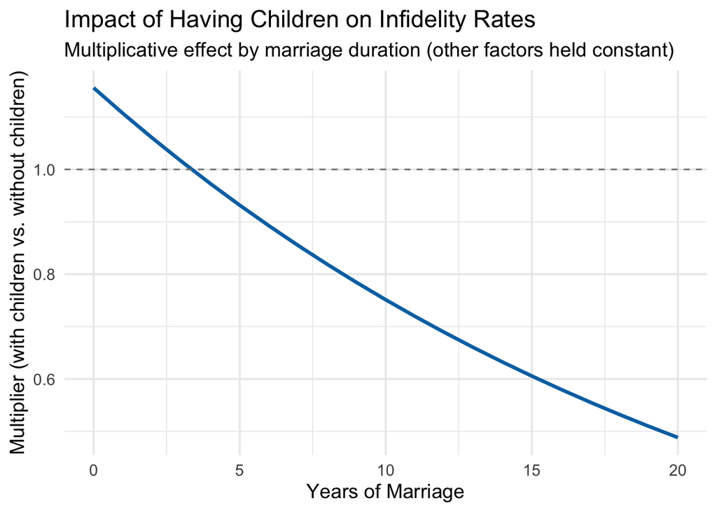

```r
# Extract coefficients
coef_kids <- coef(interaction_model)["kids"]
coef_interaction <- coef(interaction_model)["years_married_kids_interaction"]

# Define evaluation range
years <- 0:20

# Calculate multiplicative effects
multiplier <- exp(coef_kids + coef_interaction * years)

# Create visualization data
plot_data <- data.frame(
  years_married = years,
  multiplier = multiplier
)

# Generate plot
ggplot(plot_data, aes(x = years_married, y = multiplier)) +
  geom_line(color = "#0072B2", size = 1.2) +
  geom_hline(yintercept = 1, linetype = "dashed", color = "gray50") +
  labs(
    title = "Impact of Having Children on Infidelity Rates",
    subtitle = "Multiplicative effect by marriage duration (other factors held constant)",
    x = "Years of Marriage",
    y = "Multiplier (with children vs. without children)"
  ) +
  theme_minimal(base_size = 14)
```

# Polynomial Modeling: Non-linear Duration Effects

## Quadratic Marriage Duration Analysis

The numeric marriage duration variable (numeric_years_married) created previously is now supplemented with its quadratic term to explore potential non-linear relationships between marriage duration and infidelity frequency.

```r
# Create quadratic term
affairs$numeric_years_married_squared <- affairs$numeric_years_married^2
head(affairs[c("numeric_years_married", "numeric_years_married_squared")])
```

```
##   numeric_years_married numeric_years_married_squared
## 1                  10.0                        100.00
## 2                   4.0                         16.00
## 3                   1.5                          2.25
## 4                  15.0                        225.00
## 5                   4.0                         16.00
## 6                  15.0                        225.00
```

## Polynomial Model Specification

```r
# Create polynomial formula
base_formula <- base_model$formula
print(base_formula)
```

```
## naffairs ~ vryunhap + unhap + avgmarr + hapavg + antirel + notrel +
##     slghtrel + yrsmarr1 + yrsmarr2 + yrsmarr3 + yrsmarr4 + kids
```

```r
polynomial_formula <- update(base_formula, . ~ . - yrsmarr1 - yrsmarr2 - yrsmarr3 - yrsmarr4 + numeric_years_married + numeric_years_married_squared)
polynomial_formula
```

```
## naffairs ~ vryunhap + unhap + avgmarr + hapavg + antirel + notrel +
##     slghtrel + kids + numeric_years_married + numeric_years_married_squared
```

## Quadratic Model Training

```r
# Fit polynomial model
polynomial_model <- glm(polynomial_formula,
                       data = affairs,
                       family = poisson(link = "log"))

summary(polynomial_model)
```

```
##
## Call:
## glm(formula = polynomial_formula, family = poisson(link = "log"),
##     data = affairs)
##
## Coefficients:
##                                Estimate Std. Error z value Pr(>|z|)
## (Intercept)                   -1.931103   0.159969 -12.072  < 2e-16 ***
## vryunhap                       1.243198   0.153014   8.125 4.48e-16 ***
## unhap                          1.406375   0.103707  13.561  < 2e-16 ***
## avgmarr                        0.502397   0.118116   4.253 2.11e-05 ***
## hapavg                         0.365794   0.102180   3.580 0.000344 ***
## antirel                        1.381207   0.113801  12.137  < 2e-16 ***
## notrel                         0.711821   0.093049   7.650 2.01e-14 ***
## slghtrel                       0.852915   0.092415   9.229  < 2e-16 ***
## kids                          -0.235717   0.105436  -2.236 0.025376 *
## numeric_years_married          0.283674   0.039509   7.180 6.97e-13 ***
## numeric_years_married_squared -0.011011   0.002037  -5.405 6.50e-08 ***
## ---
## Signif. codes:  0 '***' 0.001 '**' 0.01 '*' 0.05 '.' 0.1 ' ' 1
##
## (Dispersion parameter for poisson family taken to be 1)
##
##     Null deviance: 2925.5  on 600  degrees of freedom
## Residual deviance: 2308.1  on 590  degrees of freedom
## AIC: 2824.1
##
## Number of Fisher Scoring iterations: 7
```

## Critical Point Analysis

To determine whether there exists a marriage duration threshold beyond which additional years decrease infidelity frequency, **the joint effect of numeric_years_married and numeric_years_married² is examined**, holding other model variables constant.

Considering the reduced model focused on these duration terms:

$$\log(\mu) = \beta_0 + \beta_1 \cdot \text{numeric_years_married} +
\beta_2 \cdot \text{numeric_years_married}^2$$

To identify the numeric_years_married value where the function reaches an extremum (minimum or maximum), **the derivative with respect to numeric_years_married is calculated and set to zero**:

$$\frac{d \log(\mu)}{d\, \text{numeric_years_married}} = \beta_1 + 2
\beta_2 \cdot \text{numeric_years_married}$$

Solving for the critical point:

$$x^* = -\frac{\beta_1}{2\beta_2}$$

The extremum nature depends on the sign of $\beta_2$:

- If $\beta_2 > 0$: The parabola is convex ($\cup$ shape), indicating a **minimum**
- If $\beta_2 < 0$: The parabola is concave ($\cap$ shape), indicating a **maximum**

```r
# Calculate critical point
coefficients <- coef(polynomial_model)
critical_point <- -coefficients["numeric_years_married"] / (2 * coefficients["numeric_years_married_squared"])
critical_point
```

```
## numeric_years_married
##              12.88093
```

# Conclusions

## Summary of Findings

This comprehensive analysis of marital infidelity using Generalized Linear Models reveals significant insights into the behavioral and demographic factors influencing extramarital relationships. The investigation successfully employed both logistic and Poisson regression approaches to examine different aspects of infidelity patterns.

## Methodological Insights

The comparison between logistic and Poisson models demonstrates the value of employing multiple GLM approaches for comprehensive behavioral analysis. Both models consistently identified marital satisfaction and religious attitudes as key predictors, reinforcing the reliability of these findings across different modeling frameworks.

The interaction analysis revealed that having children affects infidelity patterns only in conjunction with marriage duration, highlighting the importance of considering interaction effects in behavioral modeling. This finding suggests that the protective effect of children emerges primarily in longer marriages.

## Practical Implications

These findings provide valuable insights for understanding relationship dynamics and factors that influence marital stability. The identification of critical periods and protective factors can inform relationship counseling approaches and preventive interventions.

However, the model diagnostics reveal assumption violations that limit the reliability of precise individual predictions, emphasizing the need for cautious interpretation of quantitative estimates while maintaining confidence in the identified general patterns and relationships.